# Final Exam Review

EC 325: Econometrics

Prof. Caraher

Colby College

May 12, 2026

## Roadmap for Today

- **Part I:** Big Picture — Causal Inference (~15 min)
- **Part II:** OLS Extensions — Dummies, Logs, Quadratics, Interactions, Robust SEs (~20 min)
- **Part III:** Binary Outcomes — LPM and Logit (~10 min)
- **Part IV:** Panel Data and Fixed Effects (~15 min)
- **Part V:** Difference-in-Differences and Cluster-Robust SEs (~25 min)
- **Part VI:** Instrumental Variables (~15 min)
- **Part VII:** Regression Discontinuity (~10 min)
- **Part VIII:** Case Studies (~10 min)
- **Part IX:** Wrap-Up

# Part I: The Big Picture

## The Common Thread

You have learned a bunch methods this semester. On the page they look very different. They are all solving the same problem.

**The Fundamental Problem of Causal Inference**

For any unit $i$, the individual causal effect is
$$\kappa_i = Y_{1i} - Y_{0i},$$
but we only ever observe **one** of $Y_{1i}$ or $Y_{0i}$, never both.

Estimating a causal effect is therefore a problem of how we make **apples-to-apples** comparisons

## OVerview of Methods

A randomized experiment delivers the counterfactual by construction. When we cannot randomize, every other method approximates the same target:

| Method | Strategy |
| --- | --- |
| **RCT** | Random assignment eliminates selection bias |
| **OLS w/ controls** | Adjust for *observed* differences |
| **Panel FE** | Remove time-invariant unit differences |
| **DiD** | Subtract out the control-group trend |
| **IV** | Use exogenous variation to shift treatment |
| **RD** | Compare units just above vs. just below a cutoff |

The choice of method is the choice of *which assumption about unobserved confounding variables you are willing to make*.

## The Ladder of Identification

If we want to claim *causality*, here is general ordering of methods based on *how weak the assumptions about confounding variables* are:

| Rung | Method | Assumes |
| --- | --- | --- |
| Top | RCT | Random assignment (only sampling uncertainty) |
|  | RD | Smooth potential outcomes at the cutoff |
|  | IV | Exclusion: $Z$ affects $Y$ only through $D$ |
|  | DiD | Parallel trends absent treatment |
|  | Panel FE | All confounders are time-invariant |
|  | OLS w/ controls | Conditional independence: $E[\mu \mid X] = 0$ |
| Bottom | Simple comparisons | $E[Y_0 \mid D=1] = E[Y_0 \mid D=0]$ |

Stronger assumptions at the bottom give more flexibility about where data come from but are harder to defend. Weaker assumptions at the top demand a more structured research design.

## Technique vs. Research Design

**Two Different Things**

A **technique** is a statistical tool: OLS, 2SLS, logit regression, etc.

A **research design** is *an argument* that the comparison being made approximates the apples-to-apples ideal of a randomized experiment.

The same technique — OLS — supports very different research designs (nearly all of them):

- OLS on cross-sectional wages and education $\rightarrow$ correlational
- OLS on panel data with unit + time FE $\rightarrow$ panel FE design
- OLS on the same data with `distance to college` as instrument $\rightarrow$ IV design
- OLS on workers near a schooling-reform cutoff $\rightarrow$ RD design

The technique is the same in every case. The research design is what makes the estimate believable.

## A Decision Tree for Choosing a Method

Walk down this list. Stop at the first “yes”:

1. Can you randomize? $\rightarrow$ **RCT**
2. Is treatment determined by a sharp cutoff in a continuous variable? $\rightarrow$ **RD**
3. Do you observe treated and control units before *and* after the treatment event? $\rightarrow$ **DiD**
4. Do you have a credible instrument $Z$? $\rightarrow$ **IV**
5. Do you have panel data? $\rightarrow$ **Panel FE**
6. Are observed controls $X$ enough for conditional independence? $\rightarrow$ **OLS w/ controls** (cautiously)
7. Otherwise: stop, redefine the question, or gather more data

**A Useful Habit**

Ask the highest rung you can credibly claim, not the lowest.

## Quick Check

A researcher uses cross-sectional data on wages and a “took online course” indicator and reports the OLS coefficient as the causal effect of the course. What is the most important thing missing from this claim?

## Quick Check

A few states raises the minimum dropout age from 16 to 17 in 2005. You have annual wage data on workers born in many states between 1985–1995. Which design fits *best*?

## Quick Check

“We used 2SLS, so the estimate is causal.” What is the most important problem with this statement?

## Quick Check

Which assumption sits *highest* on the ladder of identification — i.e., is the weakest and easiest to defend?

# Part II: OLS Extensions

## Dummy Variables

- A **dummy** translates a qualitative trait into 0/1: $D = 1$ if the characteristic is present, $0$ otherwise
- For a categorical variable with $g$ categories, include only $g - 1$ dummies; the omitted category is the **baseline**

A dummy coefficient is the **difference in intercepts** between the group ($D=1$) and the baseline ($D=0$), holding other regressors constant.

**The dummy variable trap:** including a dummy for every category creates perfect multicollinearity with the intercept. Always omit one.

## Interpreting Dummy Variables

Consider a wage regression with a single dummy for *female*:
$$wage = \beta_0 + \beta_1 \cdot female + \beta_2 \cdot educ + \mu$$

- $\hat{\beta}_0$ = the predicted $wage$ for the **baseline group** (males) when $educ = 0$
- $\hat{\beta}_0 + \hat{\beta}_1$ = the predicted $wage$ for **females** when $educ = 0$
- $\hat{\beta}_1$ = the **gap** between females and males at any given level of $educ$

## Quick Check

You estimate $\widehat{wage} = 5.20 + 2.10 \cdot educ - 1.80 \cdot female$, where $female = 1$ for women and $0$ for men. How do you interpret $\hat{\beta}_{female} = -1.80$?

## Incorporating Non-Linearities

- Including polynomials the the RHS of a regression let’s use account for non-linear relationships between $x$ and $y$

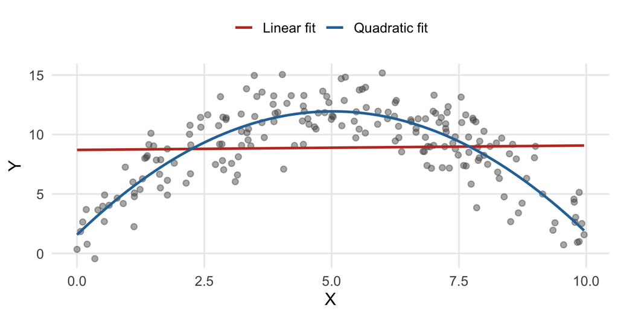

## Polynomials: Marginal Effect Depends on $X$

- Effect of $x$ on $y$ (i.e., marginal effect) depends on specific value of $x$

Wage-experience relationship:
$$wage = \beta_0 + \beta_1 \cdot exper + \beta_2 \cdot exper^2 + \mu$$

The marginal effect of one more year of experience is derivative of $wage$ w/r/t $experience$:
$$\frac{\partial \widehat{wage}}{\partial exper} = \hat{\beta}_1 + 2 \hat{\beta}_2 \cdot exper$$

To find the max value, set the marginal effect to zero:
$$exper^* = -\frac{\hat{\beta}_1}{2\hat{\beta}_2}$$

If $\hat{\beta}_2 < 0$: inverted-U. If $\hat{\beta}_2 > 0$: U-shape.

## Quick Check

For $\widehat{wage} = 4 + 0.50 \cdot exper - 0.010 \cdot exper^2$, the marginal effect of one more year of experience at $exper = 10$ is:

## Logs: Why and When

**Why log:**

- Many economic variables (wages, income, prices) are right-skewed
- Logs let us interpret coefficients in percent terms
- A 1% change in a wage means the same thing at $10/hr or $100/hr

**Approximation:** $\ln(Y_1) - \ln(Y_0) \approx \frac{Y_1 - Y_0}{Y_0}$

**This approximation only works for relatively small changes** (i.e., less than about 0.30)

For small coefficients ($|\beta| < 0.20$): $100 \cdot \beta \approx$ percent change.

For larger coefficients, use the exact formula: $100 \cdot (e^\beta - 1)$ %.

**Don’t log:** variables with zeros/negatives, rates/percentages, dummies.

## Logarithm Interpretation Cheat Sheet

| Model | Equation | Interpretation of $\hat{\beta}_1$ |
| --- | --- | --- |
| **Level-Level** | $Y = \beta_0 + \beta_1 X$ | 1-unit ↑ $X$ → $\beta_1$-unit Δ $Y$ |
| **Log-Level** | $\ln(Y) = \beta_0 + \beta_1 X$ | 1-unit ↑ $X$ → $(100\beta_1)$% Δ $Y$ |
| **Level-Log** | $Y = \beta_0 + \beta_1 \ln(X)$ | 1% ↑ $X$ → $\beta_1/100$ unit Δ $Y$ |
| **Log-Log** | $\ln(Y) = \beta_0 + \beta_1 \ln(X)$ | 1% ↑ $X$ → $\beta_1$% Δ $Y$ (elasticity) |

If you see a log on one (or both) sides of the regression, think of *percent changes*

## Quick Check

In $\ln(\widehat{wage}) = 1.5 + 0.07 \cdot educ$, an additional year of education is associated with:

## Interactions

Dummies alone shift the intercept but force both groups to share the same slope.

Interactions let the effect of one variable depend on another:
$$\ln(wage) = \beta_0 + \beta_1 \cdot female + \beta_2 \cdot educ + \beta_3 \cdot (female \times educ) + \mu$$

- Men ($female = 0$): $\ln(wage) = \beta_0 + \beta_2 \cdot educ$
- Women ($female = 1$): $\ln(wage) = (\beta_0 + \beta_1) + (\beta_2 + \beta_3) \cdot educ$

$\beta_1$ shifts the intercept; $\beta_3$ shifts the slope.

## Computing Total Effects with Interactions

When interactions are present, the total effect of a variable includes all terms where it appears.

Effect of education depends on gender:
$$\frac{\partial \ln(wage)}{\partial educ} = \beta_2 + \beta_3 \cdot female$$

- Men: $\beta_2$
- Women: $\beta_2 + \beta_3$

**Common Mistakes**

1. Reporting just $\beta_1$ as “the effect of female” — you must add $\beta_3 \cdot educ$.
2. Including $X_1 \times X_2$ without including $X_1$ and $X_2$ as main effects.

## Quick Check

In $\ln(\widehat{wage}) = 1.20 + 0.083 \cdot educ - 0.18 \cdot female + 0.015 \cdot (female \times educ)$, the return to education for women is:

## Heteroskedasticity-Robust SEs

GM 5 says $Var(\mu \mid x) = \sigma^2$ — constant variance. In economic data, that’s almost never true (income & spending, firm size & profits, experience & wages).

**What Breaks**

- Heteroskedasticity does **not** bias the OLS coefficients (GM 1–4 are enough for unbiasedness)
- It **does** bias the standard errors, usually downward
- $t$-statistics too large, $p$-values too small, Type I error inflated

## The Robust SE Formula

OLS variance assumes homoskedasticity:
$$Var(\hat{\beta}_1) = \frac{\sigma^2}{SST_x}$$

Robust (White / Huber-White / HC1) variance weights each squared residual by how far $x_i$ is from $\bar{x}$:
$$Var(\hat{\beta}_1) = \frac{\sum_{i=1}^{n} (x_i - \bar{x})^2 \hat{\mu}_i^2}{SST_x^2}$$

In `feols()`: add `vcov = "HC1"`.

The cost when not needed is small. The benefit when needed is large. Default to robust.

# Part III: Binary Outcomes

## When the Outcome is 0/1

When $y \in \{0, 1\}$:

OLS with a binary $y$ estimates a probability: $\hat{y} = \hat{P}(y = 1 \mid \mathbf{x})$.

**The Linear Probability Model (LPM)**

Run OLS with a 0/1 outcome.

$\hat{\beta}_j$ = change in the **probability** of $y = 1$ for a one-unit increase in $x_j$.

Interpret in **percentage points**, not percent. A coefficient of $-0.15$ is a 15-pp drop, not 15%.

## Two Problems with the LPM

1. **Always heteroskedastic.** $Var(\mu \mid \mathbf{x}) = p(\mathbf{x})[1 - p(\mathbf{x})]$ depends on $\mathbf{x}$. Fix with robust SEs.
2. **Out-of-bounds predictions.** A straight line can produce $\hat{p} < 0$ or $\hat{p} > 1$.

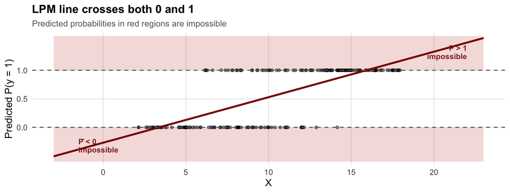

## The Logit Alternative

Wrap the linear index in the logistic function:
$$P(y = 1 \mid \mathbf{x}) = G(\beta_0 + \beta_1 x_1 + \cdots + \beta_k x_k), \quad G(z) = \frac{e^z}{1 + e^z}$$

- $G(z)$ is always in $(0, 1)$ — no out-of-bounds predictions
- Estimated by MLE, not OLS
- Coefficients are in log-odds units — not directly interpretable

## Three Ways to Read Logit Coefficients

| Interpretation | Formula | Meaning |
| --- | --- | --- |
| **Log-odds** | $\hat{\beta}_j$ | Direct but abstract; sign indicates direction |
| **Odds ratio** | $\exp(\hat{\beta}_j)$ | OR > 1 increases the odds; OR < 1 decreases |
| **Marginal effect** | $\frac{\partial P}{\partial x_j}$ | Change in **probability** — depends on starting $\mathbf{x}$ |

**Marginal Effect at the Mean**

1. Get $\hat{P}(y = 1)$ at $\bar{\mathbf{x}}$
2. Get $\hat{P}(y = 1)$ at $\bar{\mathbf{x}}$ with $x_j$ shifted by 1
3. Subtract

## LPM vs. Logit: When Do They Agree?

The logistic function is nearly linear in the middle of its range.

| Where you are | LPM and Logit |
| --- | --- |
| Near $p = 0.5$ | Marginal effects very similar |
| Near $p = 0$ or $p = 1$ | Diverge meaningfully |

| Field | Default |
| --- | --- |
| Causal inference (economics) | LPM |
| Prediction (CS, health stats) | Logit |

Either way: robust SEs.

## Quick Check

An LPM gives $\hat{\beta}_{insurance} = 0.12$ when the outcome is “saw a doctor in the past year.” What does this mean?

# Part IV: Panel Data and Fixed Effects

## What Panel Data Buys You

- **Cross-sectional:** units observed once
- **Panel:** the same units observed at multiple points in time

| Setting | Unit | Time |
| --- | --- | --- |
| State min-wage policy | State | Year |
| Worker tracking (NLSY) | Person | Year |
| Hospital quality | Hospital | Quarter |
| Stock returns | Firm | Day |

Observing the same unit over time lets us control for everything about that unit that doesn’t change, observed or unobserved.

## Between vs. Within Variation

Two sources of variation in the data:

- **Between:** comparing different units to each other (Boston vs. Miami) — confounded by all the ways they differ
- **Within:** comparing each unit to itself over time — unit-level confounders cancel

Fixed-effects methods exploit within variation for identification.

The question changes from

> *“Do cities with higher unemployment have more crime?”*

to

> *“When unemployment rises within a city, does crime rise too?”*

## The Fixed Effects Model

$$y_{it} = \beta_0 + \beta_1 x_{it} + a_i + \mu_{it}$$

- $a_i$: unit fixed effect — captures all time-invariant characteristics of unit $i$
- $\mu_{it}$: idiosyncratic error

We don’t observe $a_i$, but we can eliminate it by demeaning:
$$\ddot{y}_{it} = y_{it} - \bar{y}_i, \qquad \ddot{x}_{it} = x_{it} - \bar{x}_i$$

After demeaning, $a_i$ drops out (since $a_i - \bar{a}_i = 0$):
$$\ddot{y}_{it} = \beta_1 \ddot{x}_{it} + \ddot{\mu}_{it}$$

## Two-Way Fixed Effects

Add time fixed effects to absorb shocks common to all units in a given period:
$$y_{it} = \beta_1 x_{it} + a_i + \tau_t + \mu_{it}$$

Controls for:

**Unit FE:** Time-invariant unit characteristics **Time FE:** Unit-invariant time shocks (national recessions, federal policy)

## Other Fixed Effects

In general, a **fixed effect** is a dummy for every level of a grouping variable — it absorbs *all* variation that is constant within that group.

Common choices beyond unit and year:

- **Industry FE** — absorb permanent differences across sectors
- **Region X year FE** — absorb anything that hits a state-region (e.g., New England) in a given year
- **County × month FE** — local seasonality effects

## What FE Cannot Fix

**Three Things FE Don’t Fix**

1. **Reverse causality.** If $y$ causes $x$, FE doesn’t help.
2. **Unit-specific time-varying confounders.** A city-specific boom that drives both $x$ and $y$ remains a problem.
3. **Differential trends.** If treated and untreated units would have followed different paths, FE alone doesn’t separate that from the treatment effect.

## Quick Check

In a county-year panel, what does adding county fixed effects absorb?

# Part V: Difference-in-Differences

## The DiD Idea

DiD uses control units rather than (just) control variables.

**Natural Experiment**

A study where treatment is assigned by forces outside the researcher’s control (a policy change, an event), creating conditions that resemble random assignment.

Examples:

- Card (1990): Mariel Boatlift on Miami’s wages
- Card & Krueger (1994): NJ minimum wage increase
- Medicaid expansion under the ACA (state by year)

## The ATT and the Counterfactual

Average Treatment Effect on the Treated:
$$ATT = E[Y_{i1}(1) \mid D_i = 1] - E[Y_{i1}(0) \mid D_i = 1]$$

- We observe the first term (the treated group’s actual post outcome)
- We don’t observe the second — the counterfactual

## The Parallel Trends Assumption

**The Identifying Assumption**

In the absence of treatment, the treated group would have followed the same trend as the control group:
$$E[Y_{i1} - Y_{i0} \mid D_i = 1] = E[Y_{i1} - Y_{i0} \mid D_i = 0]$$

- LHS is unobservable — the trend the treated would have followed
- RHS is observable — the trend the control group did follow

If parallel trends hold, the control group gives us a credible counterfactual.

## Quick Check

A colleague says: “We can’t run a DiD here — the treated states have much higher baseline uninsurance than the control states.” Is this a fatal objection?

## The DiD Estimator

$$ATT = \underbrace{(E[Y_{i1} \mid D_i = 1] - E[Y_{i0} \mid D_i = 1])}_{\text{trend, treated}} - \underbrace{(E[Y_{i1} \mid D_i = 0] - E[Y_{i0} \mid D_i = 0])}_{\text{trend, control}}$$

The double difference nets out anything that would have happened had treatment not occurred.

Levels don’t matter; trends do. A control group with a different *level* of the outcome but the same pre-trend gives the right answer.

## The DiD Regression

$$y_{it} = \beta_0 + \beta_1 D_i + \beta_2 P_t + \delta(D_i \times P_t) + \mu_{it}$$

| Group | $D_i$ | $P_t$ | Predicted $\hat{y}_{it}$ |
| --- | --- | --- | --- |
| Control, Pre | 0 | 0 | $\beta_0$ |
| Control, Post | 0 | 1 | $\beta_0 + \beta_2$ |
| Treated, Pre | 1 | 0 | $\beta_0 + \beta_1$ |
| Treated, Post | 1 | 1 | $\beta_0 + \beta_1 + \beta_2 + \delta$ |

The interaction coefficient $\delta$ is the DiD estimate (the ATT).

## TWFE: The Generalization

$$y_{it} = \delta D_{it} + \alpha_i + \tau_t + \mu_{it}$$

- $D_{it} = 1$ for treated units in post-treatment periods
- $\alpha_i$: unit fixed effects
- $\tau_t$: time fixed effects

In the 2×2 case, TWFE gives the same $\hat{\delta}$ as the standard DiD regression. The advantage: TWFE generalizes to many units and many time periods.

## Event Study: Dynamic DiD

Estimate separate treatment effects for each post-treatment period:
$$y_{it} = \sum_{j=-J}^{-2}\beta_j D_{it} + \sum_{k=0}^{K}\beta_k D_{it} + \alpha_i + \tau_t + \mu_{it}$$

- $D_{it}$ in the first sum: dummy for being in the treatment group and $j$ periods before treatment
- $D_{it}$ in the second sum: dummy for being in the treatment group and $k$ periods after treatment
- Omit $j = -1$ as the reference period

| Coefficient | What It Tells You |
| --- | --- |
| $\beta_j$ for $j < -1$ | “Effect” $j$ years before treatment (should be near zero of parallel trends holds) |
| $\beta_0$ | Effect in the year of treatment |
| $\beta_k$ for $k > 0$ | Effect $k$ years after treatment |

## Reading an Event Study Plot

**Good signs:**

- Pre-treatment coefficients flat near zero
- Confidence intervals include zero
- Post-treatment effects appear and grow / persist

**Bad signs:**

- Pre-treatment coefficients trending
- Statistically significant before treatment
- Suggests groups were diverging before treatment

A non-flat pre-period in an event study is direct statistical evidence that the parallel trends assumption is violated.

## Example: A “Clean” Event Study

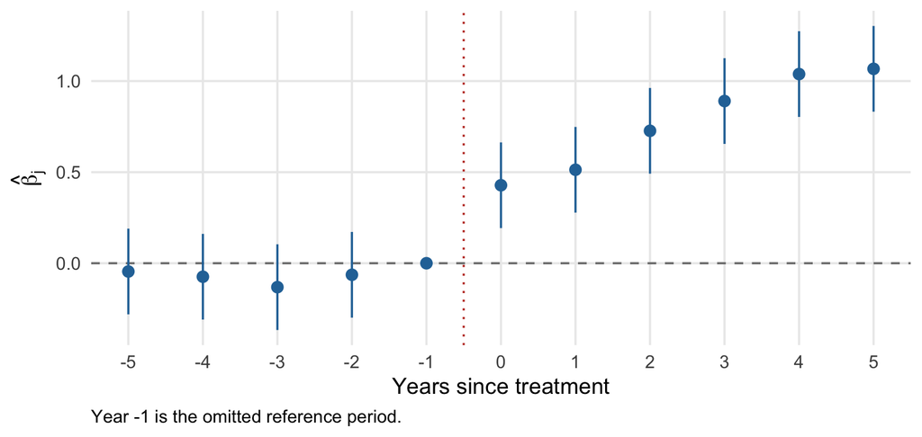

Pre-period coefficients hug zero → parallel trends look credible. Post-period coefficients are positive and grow → a real treatment effect that builds over time.

## Quick Check

In an event study, you observe that pre-treatment coefficients are statistically significant and trending upward. What does this suggest?

## Selecting Control Units

DiD is only as credible as the **control group** you pick. Two broad strategies:

**Intuitive (design-based)**

- Pick controls that are *plausibly similar* to the treated by argument, not by algorithm
- Classic example: **border-discontinuity** — compare counties just across a state line from a policy change
- Or: neighboring industries, paired schools, adjacent ZIP codes
- Defensible because the choice comes from the institutional setting

**Data-driven (statistical)**

- Let observables decide which controls “look like” the treated
- Uses data-driven algorithims to find appropriate units
- **IPW-DiD:** estimate $P(\text{treated} \mid \mathbf{x})$ and upweight controls that resemble treated units

**In Practice**

The intuitive approach is more transparent; the data-driven approach is more flexible. The strongest designs use both — choose a plausible donor pool first, then reweight or match within it.

## IPW-DiD

Inverse Propensity Weighted DiD reweights controls to look more like treated units:

1. Estimate propensity scores $\hat{P}_i = P(D_i = 1 \mid \mathbf{x}) = D_i = \beta_0 + \beta_1x_1 + ...$ from a logit regression on pre-treatment covariates
2. Compute weights:
   $$IPW_i = D_i + (1 - D_i)\frac{\hat{P}_i}{1 - \hat{P}_i}$$
3. Estimate the TWFE DiD using $IPW_i$ as observation weights

## What the IPW Weights Do

| Unit type | Weight | Logic |
| --- | --- | --- |
| Treated | 1 | Always counts |
| Control with high $\hat{P}_i$ | Large | Looks like a treated unit |
| Control with low $\hat{P}_i$ | Small | Doesn’t look like a treated unit |

The reweighted control group is observably similar to the treated group.

IPW-DiD is only as good as your propensity-score model. Leave out an important determinant, bias remains.

## Cluster-Robust SEs

A **cluster** is a group of observations whose errors are correlated within the cluster but independent across clusters.

| Individual unit | Cluster |
| --- | --- |
| Students | Classroom |
| People | State |
| Counties | State |
| Patients | Hospital |

Within-cluster correlation requires SEs that allow for arbitrary correlation within each cluster. HC1 is not enough.

## What Goes Wrong with the Wrong SEs

| What you do | Type I error rate |
| --- | --- |
| Naive (iid) SEs on clustered data | 30–50%+ |
| HC1 SEs on clustered data | Still way too high |
| Cluster-robust SEs | $\approx 5\%$ |

## Cluster-Robust SEs

How do cluster-robust SEs work?

1. *Chose level of cluster*
2. Estimate regression model
3. Compute intra-cluster correlation of error terms
4. Adjust sample size so $n$ is closer to number of highly correlated clusters
5. Compute new SE

## The Practical Rule

How do we chose the level to cluster at? It depends!

**Rule of thumb:** Cluster at the level of treatment assignment.

| Treatment level | Cluster level |
| --- | --- |
| State-level policy | State |
| School-level program | School |
| Hospital protocol | Hospital |

Need at least 20–50 clusters for CRSEs to perform well.

## Quick Check

A researcher uses a state-by-year panel of state-level minimum-wage policies on county-level employment. At what level should she cluster?

# Part VI: Instrumental Variables

## The Endogeneity Problem

OLS requires the zero conditional mean assumption: $E[\mu \mid X] = 0$.

When $Cov(X, \mu) \neq 0$, $X$ is endogenous and OLS is biased. Three classic sources:

1. **Omitted variable bias** (e.g., ability bias in returns to education)
2. **Selection bias** (healthier people buy insurance)
3. **Reverse causality** (high-crime areas hire more police)

When OLS, FE, and DiD all fail, IV is the next tool to try.

## The IV Idea

Variation in $X$ has two parts:

- **Endogenous variation** — correlated with $\mu$, biases OLS
- **Exogenous variation** — unrelated to $\mu$, what we want

**What an Instrument Does**

An instrument $Z$ shifts $X$ in a way that allows us to only use the *exogenous* part of $X$ to estimate the relationship between $X$ and $y$

## The Two IV Assumptions

| Assumption | Statement | Testable? |
| --- | --- | --- |
| **Relevance** | $Cov(Z, X) \neq 0$ — the instrument moves $X$ | ✅ via first-stage F |
| **Exclusion** | $Cov(Z, \mu) = 0$ — $Z$ affects $Y$ only through $X$ | ❌ defended with reasoning |

**The Hard Part**

Both assumptions must hold. Relevance is testable; exclusion is the one you have to argue for. Most of an IV paper is the exclusion-restriction defense.

## Example: Angrist & Evans (1998)

**Question:** Does having more kids reduce mothers’ labor supply?

- $Y$ = mom worked, $X$ = had a third child, $Z$ = **first two kids are same-sex**

**Relevance** ✅

- Parents prefer mixed-sex children, so same-sex pairs are more likely to try for a third
- Verifiable: first-stage shows same-sex raises $P(\text{3rd kid})$ by ~6 pp

**Exclusion** ⚠️

- Child sex is biological chance — uncorrelated with career orientation, husband’s earnings, etc.
- No plausible *direct* channel from “two boys” to “mom works less”
- Believable, but **untestable** — defended with biology, not statistics

## Two-Stage Least Squares

- We estimate an IV model using **2SLS**

**Stage 1:** regress $X$ on $Z$ to isolate the exogenous variation:
$$X_i = \pi_0 + \pi_1 Z_i + \nu_i \quad \Longrightarrow \quad \hat{X}_i$$

**Stage 2:** regress $Y$ on the predicted $\hat{X}_i$:
$$Y_i = \beta_0 + \beta_1 \hat{X}_i + \varepsilon_i$$

$\hat{\beta}_1^{2SLS}$ is the IV estimate.

## Weak Instruments

A weak instrument barely moves $X$. The result: wild swings in $\hat{\beta}^{2SLS}$ and unreliable inference.

Standard diagnostic: first-stage F-statistic.

| F | What it means |
| --- | --- |
| < 10 | Weak instrument — don’t trust 2SLS |
| 10 – 100 | Old rule said “fine” — modern evidence says be cautious |
| > 100 | Strong instrument |

## Quick Check: A Weak-Instrument 2SLS

```r
set.seed(325)
n <- 500
weak_df <- tibble(
  z = rnorm(n),
  u = rnorm(n),
  x = 0.05 * z + u + rnorm(n),
  y = 1 + 2 * x + u + rnorm(n)
)

weak_iv <- feols(y ~ 1 | x ~ z, data = weak_df)
fitstat(weak_iv, "ivf")
```

```
F-test (1st stage), x: stat = 0.26168, p = 0.609198, on 1 and 498 DoF.
```

The first-stage F is far below 10. What should you conclude?

## Classic IV Examples

| Study | Question | Instrument |
| --- | --- | --- |
| **Card (1995)** | Returns to education | Distance to college |
| **AJR (2001)** | Institutions and growth | Settler mortality |
| **Levitt (1997)** | Police and crime | Electoral timing |
| **Angrist & Krueger (1991)** | Returns to schooling | Quarter of birth |
| **Angrist & Evans (1998)** | Children → women’s labor supply | Same-sex first two children |

In each case: a research question that OLS can’t answer, an instrument that shifts treatment, and an exclusion-restriction story to defend.

# Part VII: Regression Discontinuity

## The RD Idea

Modern life is full of rigid rules and cutoffs:

- Turn 21 → legal drinking
- Score 70+ on an exam → admitted to a selective school
- Income below $X → qualify for Medicaid
- 50.01% vote share → win the election

At each cutoff, treatment flips on or off abruptly. Units just above and just below are nearly identical except for treatment.

Rigid rules generate natural experiments. Compare units just below the cutoff (control) to units just above (treated) and read off the jump.

## Vocabulary

| Term | Definition |
| --- | --- |
| **Running variable** | The continuous variable that determines treatment (age, score, income) |
| **Cutoff (threshold)** | The value at which treatment flips |
| **Sharp RD** | Treatment is a deterministic function of the running variable |
| **Fuzzy RD** | The cutoff shifts the probability of treatment (handled with IV — beyond this course) |

## The Sharp RD Regression

$$Y_a = \alpha + \rho D_a + \gamma a + e_a$$

- $D_a = 1$ if $a \geq a_0$
- $\gamma a$ controls for the smooth trend in the running variable
- $\rho$ — the vertical jump at the cutoff — is the causal estimate

The whole identification argument is about modeling the trend correctly.

## True Jump vs. “Jump” from Non-Linearity

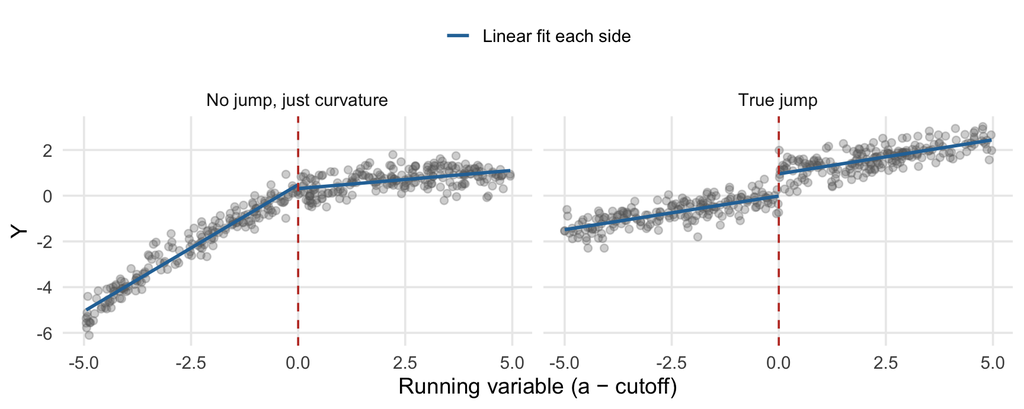

## Dealing With Non-Linearity

Two complementary strategies for telling a real jump from a fitting artifact:

**1. Model the curvature on each side**

- Add interactions so the slope can differ across the cutoff: $\gamma_1 a + \gamma_2 (D \cdot a)$
- Add a quadratic in $a$ if the trend is clearly curved
- If $\hat{\rho}$ is stable across linear, slope-interaction, and quadratic fits → the jump is robust

**2. Zoom in to a narrow bandwidth**

- Restrict the sample to $|a - a_0| \leq h$ for some small $h$
- Close to the cutoff, any smooth function is approximately linear → curvature matters less
- Trade-off: smaller $h$ → less bias from misspecification, but fewer observations and noisier estimate

**Best Practice**

Report estimates across several bandwidths *and* functional forms. A credible RD jump survives both.

## The Identifying Assumption

**Smoothness at the Cutoff**

In the absence of treatment, all other determinants of the outcome would vary smoothly through the cutoff. Any jump at the threshold can therefore be attributed to the treatment.

This gets violated when:

- Units manipulate their position to be just above (or below) the cutoff
- The cutoff coincides with another policy change
- Pre-determined characteristics jump at the cutoff (covariate balance fails)

## Quick Check

A merit scholarship is awarded to students with high-school GPA $\geq 3.0$. Let $a = \text{GPA} - 3.0$ and $D_a = \mathbf{1}\{a \geq 0\}$. The estimated sharp RD model is
$$\widehat{college\_GPA} = 2.50 + 0.20 \, D_a + 0.30 \, a.$$

How do you interpret $\hat{\rho} = 0.20$?

# Part VIII: Putting It All Together

## Same Question, Different Designs

A mature literature attacks one question with multiple methods and reasons about the consistency of the estimates.

We’ll look at two questions you’ve seen all semester:

1. Does health insurance improve health?
2. Does education raise wages?

For each one, every method on the ladder gives a slightly different answer.

## Case Study 1: Insurance and Health

| Method | What It Does | Threat |
| --- | --- | --- |
| **Naive OLS** | Compare insured vs. uninsured | Confounded by income, education |
| **OLS w/ controls** | Add demographic controls | Risk aversion, health literacy still missing |
| **Panel FE** | Compare same person before/after coverage | Health-shock-induced enrollment |
| **DiD** | Compare ACA-expansion vs. non-expansion states | Parallel trends |
| **RD** | Medicare at age 65; Oregon Medicaid lottery cutoffs | Smoothness at cutoff |
| **RCT** | Oregon Health Insurance Experiment lottery | The gold standard |

Each method gives a slightly different number for a slightly different population.

## Case Study 2: Education and Wages

| Method | What It Does | Threat |
| --- | --- | --- |
| **Naive OLS** | Mincer return: ≈ 8–10% per year | Ability bias |
| **OLS w/ controls** | Add IQ proxies, parental education | Ability not fully observable |
| **Panel FE** | Person-level panels | Education barely varies within an adult |
| **DiD** | Compulsory schooling laws by state-cohort | Need clean variation |
| **IV** | Quarter-of-birth, distance to college, draft lottery | Exclusion restriction |
| **RD** | School-entry age cutoffs; selective-admissions cutoffs | Local at the cutoff |
| **RCT** | Perry Preschool, scholarship lotteries | Often impossible at scale |

## A Field Guide: Questions to Ask Before Running a Regression

1. What is the causal question in plain English?
2. What is the outcome and the treatment?
3. What is the data structure? Cross-section, panel, time series?
4. Where does the variation in treatment come from?
5. What is the strongest identification strategy you can honestly deploy?
6. What is the identifying assumption, and how will you defend it?
7. What is the estimand?
8. Are your standard errors appropriate? Robust? Clustered?
9. What specification checks will you run?
10. What is the one sentence you could honestly write in the abstract?

# Part IX: Wrap-Up

## Key Formulas to Know

| Formula | What It Measures |
| --- | --- |
| $\hat{\beta}_1 = \frac{Cov(x,y)}{Var(x)}$ | OLS slope |
| $Bias = \beta_2 \cdot \delta_1$ | Omitted variable bias |
| $Var(\hat{\beta}_j) = \frac{\sigma^2}{SST_j(1-R_j^2)}$ | Estimator variance |
| $t = \hat{\beta}_j / se(\hat{\beta}_j)$ | T-statistic |
| Quadratic peak: $x^* = -\hat{\beta}_1 / (2\hat{\beta}_2)$ | Where the curve turns |
| $ATT = \delta$ in DiD | Treatment effect on the treated |
| First-stage F | Instrument strength check |
| RD jump $= \rho$ | Causal effect at the cutoff |

## A Few Things to Carry With You

- Every method is a strategy for approximating the RCT we usually can’t run. It can be useful to think about what the “ideal experiment” would be, and you can think about how to sue thee methods to best approximate it.
- Method choice = which assumption about unobservables you are willing to make.
- There is no universally best method. There is the best method *for your question and your data*.
- A research design is a credible argument, not a technique.
- Robust standard errors for your setting are a professional minimum.
- Read empirical papers with the identification question first, methods second, numbers last.